# Multiplex Canada Predictive Projection

In this analysis we select candidate submodels from the reference model containing all variables ($p=$ 20) using predictive projection on the training (development) data. Then, we validate their performance from predicted (i.e sensitivity/specificity) or fitted (i.e AUC) values of the posterior of each submodel applied to testing (validation) data.

Note: the final performance measures may change slightly from the manuscript measures because the sampling frame changes for each run and because I used 5-fold CV to reduce rendering time.

## Set-up

```r
knitr::opts_knit$set(root.dir = "~/R files/multiplex canada")
# to ensure that the project is at the root directory
knitr::opts_chunk$set(echo = TRUE, warning = F, fig.width=14, fig.height=18, message = F)
```

### Packages

```r
library(projpred) # main package
library(brms) # for bayesian statistics
library(tidyverse) # for tidy format
library(bayesplot) # to plot bayesian models
theme_set(bayesplot::theme_default(base_family = "sans"))
require(mice)
# require(loo)
```

### Load imputed data and functions

```r
mice1l<- read.csv("3_intermediate/imputed/imputed_data_long_no_prom_1l.csv")
mice_obj<- as.mids(mice1l)  # load the imputed data
source("2_scripts/00_functions.R") # functions
```

## Imputed data

Imputated data using 1-level predictive selection for binary variables.

### Select training vs testing dataset

```r
pooled.imp<- complete(mice_obj) # pool imputed data


unique_ids_imp<-pooled.imp$p_id

# Stratified sampling using dplyr
training_set_imp <- pooled.imp %>%
  group_by(site) %>%
  sample_frac(0.75, replace = FALSE) %>%
  ungroup() %>%
  arrange(p_id)

sampled_ids_imp <- training_set_imp$p_id

# testing set from the non-selected variables
testing_set_imp <- pooled.imp %>%
  filter(!p_id %in% sampled_ids_imp)


## check
length(unique_ids_imp) == length(unique(append(training_set_imp$p_id, testing_set_imp$p_id)))
```

```
[1] TRUE
```

### Fitting a reference model

First we create a column with outcome of interest (STBBI status)

```r
training_set_imp <- training_set_imp %>%
  mutate(stbbi.pos = case_when(
    hcv.pos %in% 1~1,
    hiv.pos %in% 1~1,
    syphilis.pos %in% 1 ~1,
    T ~0),
    TypePastSTD = case_when(
      TypePastSTD %in% "None" ~ as.factor(TypePastSTD),
      TypePastSTD %in% "6-Other" ~ "Not specified",
      T ~ "Specified"
    )) %>%
  select(- c(new.hcv, new.syphilis, new.hiv, p_id, Date.Recruited, syphilis.pos, hcv.pos, hiv.pos)) %>%
   mutate_if(is.character, as.factor)


summary(training_set_imp)
```

```
                   SexualActivity   CondomUse     SexualPartners
 0-No or no wish to answer: 78    0-Never: 82   0 to 5   :246
 1-Yes                    :218    1-Ever :214   6 or more: 50




                PastSTD           TypePastSTD                   PastInjectDrugs
 0-No or do not know:159   None         :159   0-No or no wish to answer:192
 1-Yes              :137   Not specified: 22   1-Yes                    :104
                           Specified    :115



 ShareNeedles               Alcohol                           PastHIVTest
 0-No :234    0-No              :156   0-No                         : 42
 1-Yes: 62    1-5 times per week:140   1-Yes; less than 6 months ago:105
                                       2-Yes; 6 months to 1 year ago: 35
                                       3-Yes; more than 1 year ago  :114


                        PastHCVTest                       PastSyphilisTest
 0-No                         : 31   0-No                         :  3
 1-Yes; less than 6 months ago:104   1-Yes; less than 6 months ago: 95
 2-Yes; 6 months to 1 year ago: 37   2-Yes; 6 months to 1 year ago: 34
 3-Yes; more than 1 year ago  :124   3-Yes; more than 1 year ago  :164


              PastSyphilis           Age                Gender
 0-No or do not know:256   18 to 34    :135   1-Male       :216
 1-Yes              : 40   35 and above:161   2-Female     : 64
                                              3-Transgender:  7
                                              5-No response:  9


                                                                    Descent
 Mediterranean European, African, Latin American, Caribbean and/or Asian: 91
 Non-Mediterranean European/North American                              :205




                EducationStatus                  WorkStatus
 4-Post-graduate degree : 92    Currently employed    :149
 No post-graduate degree:204    Not currently employed:147




          MonthlyIncomeStatus CurrentPartner      site          stbbi.pos
 $2000 CAD and above:109      0-No :193      Min.   :0.0000   Min.   :0.0000
 1-<$2;000 CAD      :187      1-Yes:103      1st Qu.:0.0000   1st Qu.:0.0000
                                             Median :0.0000   Median :0.0000
                                             Mean   :0.4155   Mean   :0.1689
                                             3rd Qu.:1.0000   3rd Qu.:0.0000
                                             Max.   :1.0000   Max.   :1.0000
```

**Note:** There are stbbi positive individuals in the training sample

Same for testing

```r
testing_set_imp <- testing_set_imp %>%
mutate(stbbi.pos = case_when(
    hcv.pos %in% 1~1,
    hiv.pos %in% 1~1,
    syphilis.pos %in% 1 ~1,
    T ~0),
    TypePastSTD = case_when(
      TypePastSTD %in% "None" ~ as.factor(TypePastSTD),
      TypePastSTD %in% "6-Other" ~ "Not specified",
      T ~ "Specified"
    )) %>%
  select(- c(new.hcv, new.syphilis, new.hiv, p_id, Date.Recruited, syphilis.pos, hcv.pos, hiv.pos)) %>%
   mutate_if(is.character, as.factor)

## check
ncol(testing_set_imp) == ncol(training_set_imp)
```

```
[1] TRUE
```

```r
summary(testing_set_imp)
```

```
                   SexualActivity   CondomUse    SexualPartners
 0-No or no wish to answer:26     0-Never:28   0 to 5   :88
 1-Yes                    :73     1-Ever :71   6 or more:11




                PastSTD          TypePastSTD                  PastInjectDrugs
 0-No or do not know:65   None         :66   0-No or no wish to answer:62
 1-Yes              :34   Not specified: 4   1-Yes                    :37
                          Specified    :29



 ShareNeedles               Alcohol                          PastHIVTest
 0-No :74     0-No              :53   0-No                         :15
 1-Yes:25     1-5 times per week:46   1-Yes; less than 6 months ago:33
                                      2-Yes; 6 months to 1 year ago:11
                                      3-Yes; more than 1 year ago  :40


                        PastHCVTest                      PastSyphilisTest
 0-No                         :13   0-No                         : 1
 1-Yes; less than 6 months ago:33   1-Yes; less than 6 months ago:30
 2-Yes; 6 months to 1 year ago:11   2-Yes; 6 months to 1 year ago:12
 3-Yes; more than 1 year ago  :42   3-Yes; more than 1 year ago  :56


              PastSyphilis           Age               Gender
 0-No or do not know:91    18 to 34    :41   1-Male       :67
 1-Yes              : 8    35 and above:58   2-Female     :28
                                             3-Transgender: 2
                                             5-No response: 2


                                                                    Descent
 Mediterranean European, African, Latin American, Caribbean and/or Asian:20
 Non-Mediterranean European/North American                              :79




                EducationStatus                  WorkStatus
 4-Post-graduate degree :29     Currently employed    :50
 No post-graduate degree:70     Not currently employed:49




          MonthlyIncomeStatus CurrentPartner      site          stbbi.pos
 $2000 CAD and above:31       0-No :55       Min.   :0.0000   Min.   :0.0000
 1-<$2;000 CAD      :68       1-Yes:44       1st Qu.:0.0000   1st Qu.:0.0000
                                             Median :0.0000   Median :0.0000
                                             Mean   :0.4141   Mean   :0.2222
                                             3rd Qu.:1.0000   3rd Qu.:0.0000
                                             Max.   :1.0000   Max.   :1.0000
```

There are infected individuals in the testing dataset.

Assign priors and formula

```r
xvar <- training_set_imp %>%
  select(-c(stbbi.pos)) %>%
  colnames()
# Prior guess for the number of relevant (i.e., non-zero) regression
# coefficients:
p0 <- 5
# Number of observations:
N <- nrow(training_set_imp)
# number of regression coefficients
D <- length(xvar)
# Hyperprior scale for tau, the global shrinkage parameter (note that for the
# Gaussian family, 'rstanarm' will automatically scale this by the residual
# standard deviation):
tau0 <- p0 / (D - p0) * 1 / sqrt(N)
prior_hs <- horseshoe(scale_global = tau0)

formula <- reformulate(setdiff(c(xvar), "stbbi.pos"), response = "stbbi.pos")

model_imp_hs <- brms::brm(formula,
                       data = training_set_imp,
                       family = bernoulli(link = "logit"), # binomial data
                       prior = set_prior(prior_hs),
                       seed = 0901,
                       verbose = F,
                       refresh=0)
```

#### LOO measures

```r
#we load loo here because it interacts with brms and projpred in a way that change the results. We then need to unload it when we are done
require(loo)

model0_imp <- update(model_imp_hs, formula = stbbi.pos ~ 1,  verbose = F, seed=0901)
loo0 <- loo(model0_imp, save_psis = T)

loo_imp_hs <- loo(model_imp_hs, save_psis = TRUE)

loo_imp_hs
```

```
Computed from 4000 by 296 log-likelihood matrix

         Estimate   SE
elpd_loo   -111.6 10.0
p_loo        11.1  1.4
looic       223.2 19.9
------
Monte Carlo SE of elpd_loo is 0.1.

Pareto k diagnostic values:
                         Count Pct.    Min. n_eff
(-Inf, 0.5]   (good)     295   99.7%   1342
 (0.5, 0.7]   (ok)         1    0.3%   3195
   (0.7, 1]   (bad)        0    0.0%   <NA>
   (1, Inf)   (very bad)   0    0.0%   <NA>

All Pareto k estimates are ok (k < 0.7).
See help('pareto-k-diagnostic') for details.
```

```r
loo_compare(loo0, loo_imp_hs)
```

```
             elpd_diff se_diff
model_imp_hs   0.0       0.0
model0_imp   -23.8       6.5
```

```r
detach("package:loo", unload=TRUE)
# check that it was removed
 (.packages())
```

```
 [1] "arsenal"   "pROC"      "caret"     "lattice"   "mice"      "bayesplot"
 [7] "lubridate" "forcats"   "stringr"   "dplyr"     "purrr"     "readr"
[13] "tidyr"     "tibble"    "ggplot2"   "tidyverse" "brms"      "Rcpp"
[19] "projpred"  "stats"     "graphics"  "grDevices" "utils"     "datasets"
[25] "methods"   "base"
```

### Posterior predictive check

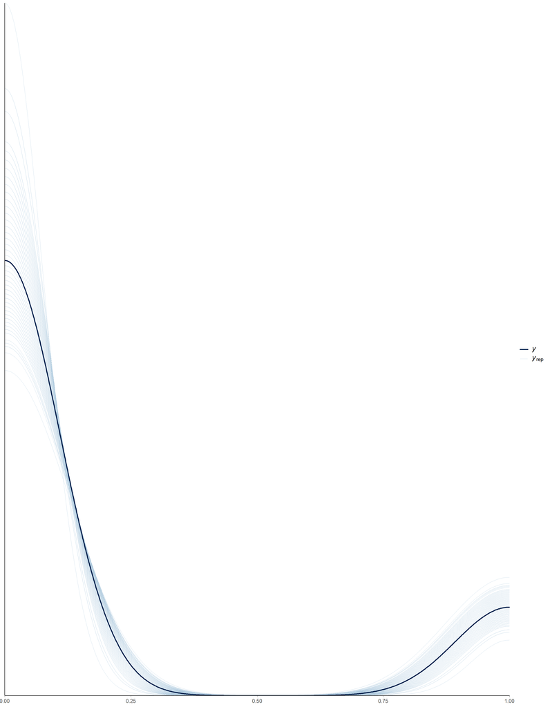

```r
ref_obj_hs<- model_imp_hs

prj_ref <- project(
  ref_obj_hs,
  verbose = F,
  predictor_terms = xvar
  )

prj_predict <- proj_predict(prj_ref)

# Using the 'bayesplot' package:
ppc_imp <- ppc_dens_overlay(y = training_set_imp$stbbi.pos, yrep = prj_predict)

ppc_imp
```

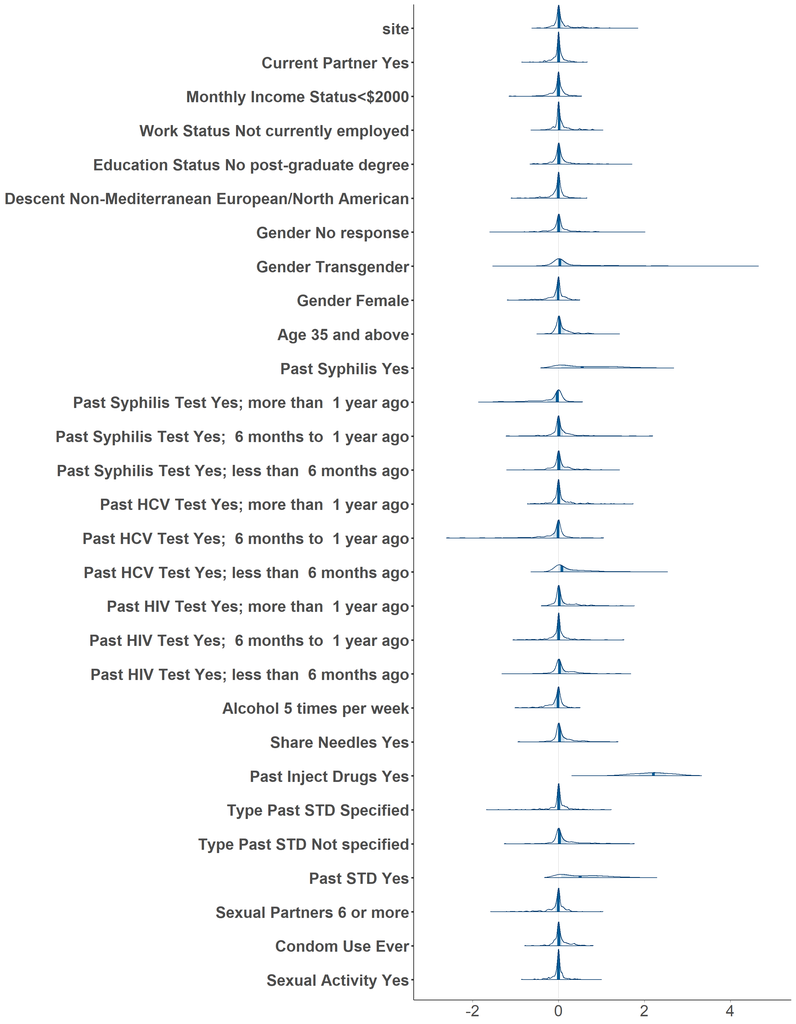

```r
# turn into matrix
prj_mat <- as.matrix(prj_ref)

# extract and clean the variable names

col <- colnames(prj_mat[,2:30])
#clean colnames
new_col<- str_replace_all(col, "(b_|\\d+-)| CAD", "") %>%
  str_replace_all("(?<!\\b(?:HCV|HIV|STD|CAD))(?<=\\w)(?=[A-Z])|(?<=\\D)(?=\\d)", " ") %>%
  str_replace_all(" 2; 000", "2000") %>%
  str_replace_all("H I V", "HIV") %>%
  str_replace_all("H C V", "HCV") %>%
  str_replace_all("S T D", "STD")

# to see the posterior distribution of each beta coefficient
mcmc_imp <- mcmc_areas(prj_mat[,2:30])+
  scale_y_discrete(label= new_col)+ # add new column names
  xaxis_text(size= 20)+
  yaxis_text(size = 20)

mcmc_imp
```

### Variable selection

#### Fast horseshoe prior

```r
model_fast_imp_hs <- cv_varsel(
  model_imp_hs,
  validate_search = F,
  method = "L1",
  verbose = FALSE, # remove the text
)

model_fast_imp_hs
```

```
Family: binomial
Link function: logit

Formula: stbbi.pos ~ SexualActivity + CondomUse + SexualPartners + PastSTD +
    TypePastSTD + PastInjectDrugs + ShareNeedles + Alcohol +
    PastHIVTest + PastHCVTest + PastSyphilisTest + PastSyphilis +
    Age + Gender + Descent + EducationStatus + WorkStatus + MonthlyIncomeStatus +
    CurrentPartner + site
Observations: 296
Projection method: traditional
CV method: PSIS-LOO CV with search not included (i.e., a full-data search only)
Search method: L1
Maximum submodel size for the search: 19
Number of projected draws in the search: 1 (from clustered projection)
Number of projected draws in the performance evaluation: 400
Argument `refit_prj`: TRUE

Submodel performance evaluation summary with `deltas = FALSE` and `cumulate = FALSE`:
 size ranking_fulldata cv_proportions_diag elpd elpd.se elpd.diff elpd.diff.se
    0      (Intercept)                  NA -135    10.3   -23.719         6.45
    1  PastInjectDrugs                  NA -115    10.0    -3.682         3.25
    2          PastSTD                  NA -112     9.9    -0.078         2.08
    3      TypePastSTD                  NA -112    10.0    -0.665         2.05
    4     PastSyphilis                  NA -111     9.7     0.900         1.45
    5      PastHCVTest                  NA -110     9.9     1.340         0.69
    6     ShareNeedles                  NA -110     9.8     1.286         0.62
    7      PastHIVTest                  NA -111     9.9     1.080         0.57
    8 PastSyphilisTest                  NA -111     9.9     0.870         0.52
    9              Age                  NA -111     9.9     0.775         0.47
   10          Alcohol                  NA -111     9.9     0.701         0.42
   11           Gender                  NA -111     9.8     0.750         0.34
   12       WorkStatus                  NA -111     9.8     0.611         0.29
   13             site                  NA -111     9.8     0.526         0.28
   14   SexualActivity                  NA -111     9.8     0.369         0.28
   15   SexualPartners                  NA -111     9.9     0.181         0.23
   16  EducationStatus                  NA -112     9.9     0.033         0.22
   17          Descent                  NA -112     9.9    -0.106         0.18
   18        CondomUse                  NA -112     9.9    -0.181         0.17
   19   CurrentPartner                  NA -112     9.9    -0.265         0.17

Reference model performance evaluation summary with `deltas = FALSE`:
   elpd elpd.se
   -112      10
```

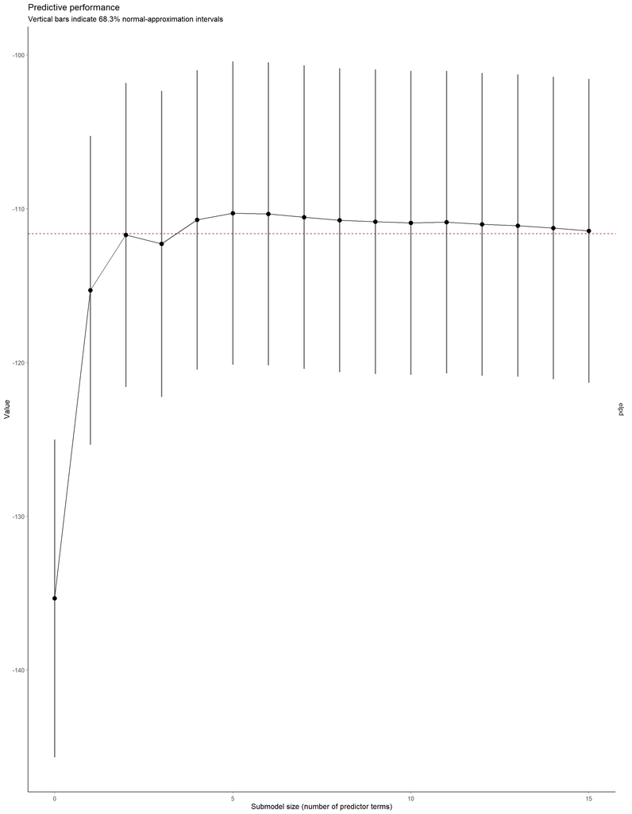

Submodels accuracy using rapid variable selection. The Y-axis represents estimated log predictive density (elpd) which is a performance statistic. The dashed red line represents the reference model performance

```r
plot(model_fast_imp_hs, stats = "elpd", ranking_nterms_max = NA)
```

#### 5-fold cross validation

For the manuscript, I used the k-fold=n validation but to reduce rendering time, I use 5-fold validation in this version

```r
cv_fits_imp <- run_cvfun(
  model_imp_hs  # 5k is default
)

# Final cv_varsel() run:
model_imp_nk <- cv_varsel(
  model_imp_hs,
  cv_method = "kfold",
  cv_fits = cv_fits_imp,
  method = "forward",
  nterms_max = 15,
  verbose = F
)

model_imp_nk
```

```
Family: binomial
Link function: logit

Formula: stbbi.pos ~ SexualActivity + CondomUse + SexualPartners + PastSTD +
    TypePastSTD + PastInjectDrugs + ShareNeedles + Alcohol +
    PastHIVTest + PastHCVTest + PastSyphilisTest + PastSyphilis +
    Age + Gender + Descent + EducationStatus + WorkStatus + MonthlyIncomeStatus +
    CurrentPartner + site
Observations: 296
Projection method: traditional
CV method: K-fold CV with K = 5 and search included (i.e., fold-wise searches)
Search method: forward
Maximum submodel size for the search: 15
Number of projected draws in the search: 20 (from clustered projection)
Number of projected draws in the performance evaluation: 400
Argument `refit_prj`: TRUE

Submodel performance evaluation summary with `deltas = FALSE` and `cumulate = FALSE`:
 size ranking_fulldata cv_proportions_diag elpd elpd.se elpd.diff elpd.diff.se
    0      (Intercept)                  NA -135    10.3   -26.056         6.52
    1  PastInjectDrugs                 1.0 -114    10.0    -5.332         2.92
    2      TypePastSTD                 0.8 -112    10.0    -2.688         1.96
    3     PastSyphilis                 0.2 -110     9.9    -0.719         1.28
    4      PastHCVTest                 0.4 -108     9.7     1.255         0.91
    5           Gender                 0.2 -109    10.1    -0.178         0.71
    6              Age                 0.0 -110    10.1    -0.996         0.67
    7 PastSyphilisTest                 0.2 -110    10.0    -0.651         0.59
    8             site                 0.0 -110    10.0    -0.720         0.60
    9          PastSTD                 0.0 -110     9.9    -0.714         0.62
   10      PastHIVTest                 0.2 -109     9.9    -0.434         0.51
   11     ShareNeedles                 0.0 -109     9.9    -0.316         0.47
   12          Alcohol                 0.2 -109     9.8    -0.182         0.38
   13  EducationStatus                 0.2 -109     9.8    -0.063         0.34
   14          Descent                 0.0 -109     9.8     0.120         0.24
   15   SexualPartners                 0.0 -109     9.8     0.149         0.21

Reference model performance evaluation summary with `deltas = FALSE`:
   elpd elpd.se
 -108.9     9.8
```

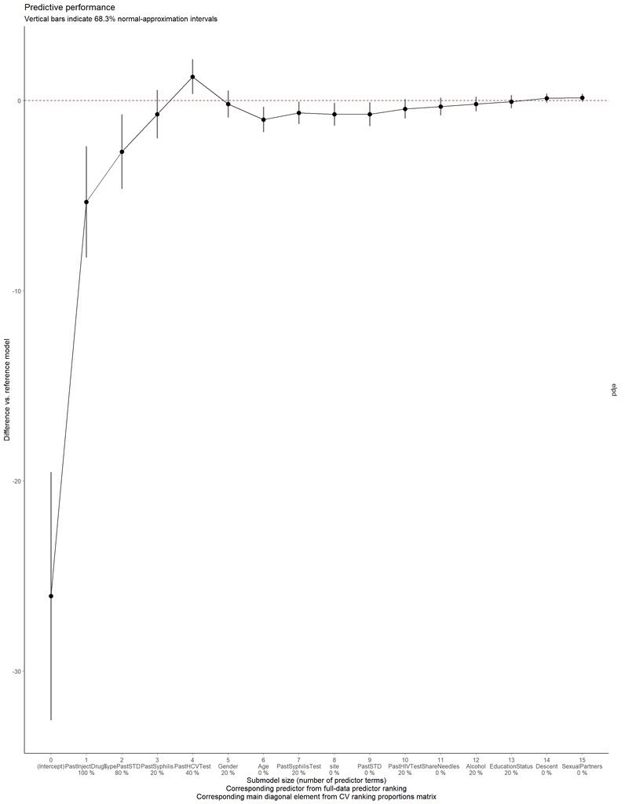

```r
performance_imp <- plot(model_imp_nk, stats = "elpd", delta = T)
performance_imp
```

#### Variable selection k-fold = sample size

Used this method because LOO package is not supported within projpred

```r
# cv_fits <- run_cvfun(
#   model_imp_hs,
#   K = nrow(training_set_imp))
#
# model_imp_nk <- cv_varsel(
#   model_imp_hs,
#   cv_method = "kfold",
#   cv_fits = cv_fits,
#   nterms_max = 15, # to be safe
#   method = "forward",
#   verbose = F
# )
#
# model_imp_nk
#
# performance_imp <- plot(model_imp_nk, stats = "elpd", delta = T)
# performance_imp
```

### Cross-validation results

```r
ranking_imp <- ranking(model_imp_nk)
```

The predictors are ranked in the following order: PastInjectDrugs, TypePastSTD, PastSyphilis, PastHCVTest, Gender, Age, PastSyphilisTest, site, PastSTD, PastHIVTest, ShareNeedles, Alcohol, EducationStatus, Descent, SexualPartners

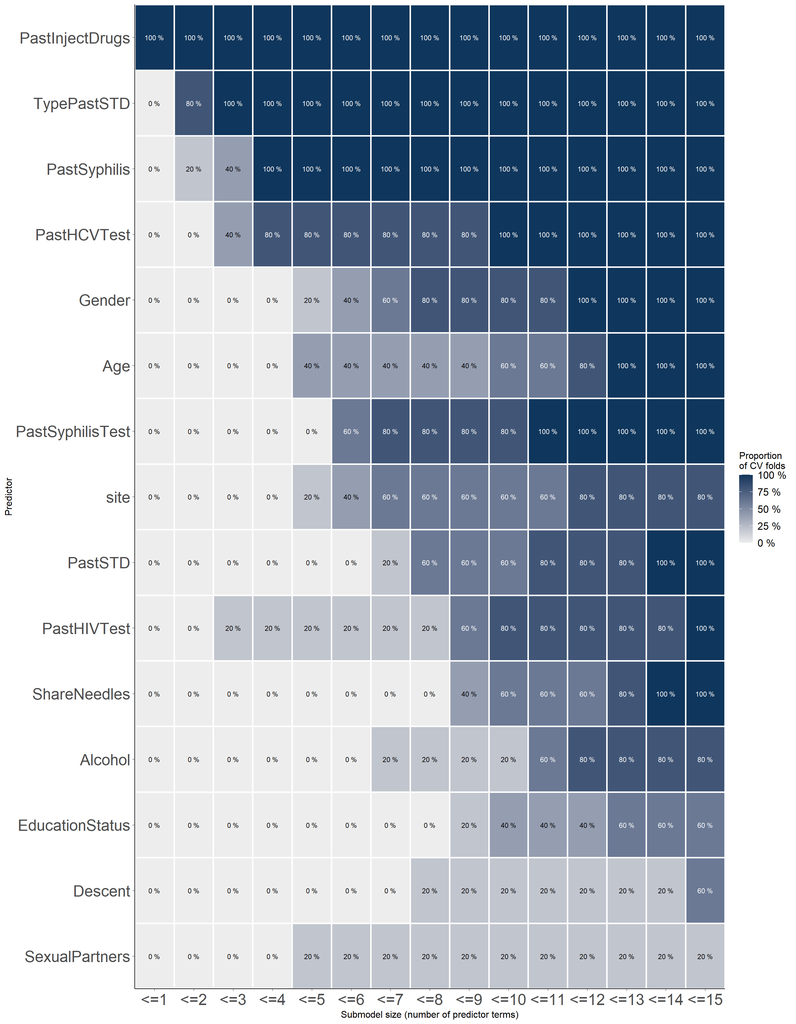

The cumulative agreement of the ranking in each cross-validation fold

```r
cumul_ranking_imp <- plot(cv_proportions(ranking_imp, cumulate = T))+
  xaxis_text(size= 20)+
  yaxis_text(size = 20)
cumul_ranking_imp
```

There is a lot of variability in predictor ranking between folds.

### Select model

```r
sugg.size <- suggest_size(model_imp_nk, stat = "elpd")

size <- 9


predictors_final_imp <- head(ranking_imp[["fulldata"]], size)
```

The suggested size for the model is 3 but we will use with the predictors in the following order PastInjectDrugs, TypePastSTD, PastSyphilis, PastHCVTest, Gender, Age, PastSyphilisTest, site, PastSTD

### Prediction performance

#### Training data

Sensitivity and specificity of our selected model

```r
# use the submodel function
sub_train<- submodels_train(model_imp_hs, predictor_ranking = predictors_final_imp, new_data = training_set_imp)

# measure sensitivity, specificity and AUC using cindy's formula for all models
sub_train
```

```
[[1]]
 Family: bernoulli
  Links: mu = logit
Formula: stbbi.pos ~ PastInjectDrugs
   Data: training_set_imp (Number of observations: 296)
  Draws: 4 chains, each with iter = 2000; warmup = 1000; thin = 1;
         total post-warmup draws = 4000

Population-Level Effects:
                     Estimate Est.Error l-95% CI u-95% CI Rhat Bulk_ESS
Intercept               -2.64      0.29    -3.25    -2.11 1.00     1657
PastInjectDrugs1MYes     2.04      0.36     1.34     2.76 1.00     2916
                     Tail_ESS
Intercept                2243
PastInjectDrugs1MYes     2730

Draws were sampled using sampling(NUTS). For each parameter, Bulk_ESS
and Tail_ESS are effective sample size measures, and Rhat is the potential
scale reduction factor on split chains (at convergence, Rhat = 1).

[[2]]
 Family: bernoulli
  Links: mu = logit
Formula: stbbi.pos ~ PastInjectDrugs + TypePastSTD
   Data: training_set_imp (Number of observations: 296)
  Draws: 4 chains, each with iter = 2000; warmup = 1000; thin = 1;
         total post-warmup draws = 4000

Population-Level Effects:
                        Estimate Est.Error l-95% CI u-95% CI Rhat Bulk_ESS
Intercept                  -3.00      0.41    -3.84    -2.27 1.00     1731
PastInjectDrugs1MYes        2.06      0.38     1.34     2.82 1.00     3168
TypePastSTDNotspecified     0.92      0.63    -0.04     2.15 1.00     1250
TypePastSTDSpecified        0.59      0.45    -0.07     1.49 1.00     1116
                        Tail_ESS
Intercept                   2408
PastInjectDrugs1MYes        3444
TypePastSTDNotspecified     1582
TypePastSTDSpecified        1266

```

[output cut: 344 more lines]

```
PastSyphilis1MYes                                  1.94 1.00     1697     3003
Age35andabove                                      0.72 1.00     3327     3647
Gender2MFemale                                     0.25 1.00     3902     3611
Gender3MTransgender                                2.79 1.00     1848     3360
Gender5MNoresponse                                 0.90 1.00     4490     3348
DescentNonMMediterraneanEuropeanDNorthAmerican     0.26 1.00     4134     3049
EducationStatusNopostMgraduatedegree               0.72 1.00     3964     3534
WorkStatusNotcurrentlyemployed                     0.61 1.00     4023     3480
MonthlyIncomeStatus1M<$2;000CAD                    0.29 1.00     4465     3417
CurrentPartner1MYes                                0.36 1.00     5275     3591
site                                               0.90 1.00     3162     3158

Draws were sampled using sampling(NUTS). For each parameter, Bulk_ESS
and Tail_ESS are effective sample size measures, and Rhat is the potential
scale reduction factor on split chains (at convergence, Rhat = 1).
```

```r
colnames <- c(paste0("model",1:length(predictors_final_imp)), "ref")

submodels.sens<- mult.sens(training_set_imp$stbbi.pos, sub_train) # 2000 iter default
submodels.sens
```

```
   rowname       Q50      Q5.5     Q94.5      Q2.5     Q97.5
1   model1 0.8536585 0.8130081 0.8983740 0.7967480 0.9065041
2   model2 0.8617886 0.8170732 0.9024390 0.8048780 0.9105691
3   model3 0.8658537 0.8170732 0.9065041 0.8089431 0.9146341
4   model4 0.8658537 0.8252033 0.9024390 0.8130081 0.9105691
5   model5 0.8658537 0.8252033 0.9024390 0.8130081 0.9105691
6   model6 0.8658537 0.8211382 0.9065041 0.8089431 0.9106707
7   model7 0.8658537 0.8252033 0.9024390 0.8130081 0.9106707
8   model8 0.8658537 0.8211382 0.9065041 0.8089431 0.9146341
9   model9 0.8699187 0.8252033 0.9065041 0.8130081 0.9186992
10     ref 0.8658537 0.8170732 0.9065041 0.8048780 0.9146341
```

```r
submodels.spec<- mult.spec(training_set_imp$stbbi.pos, sub_train) # 2000 iter default
submodels.spec
```

```
   rowname  Q50   Q5.5 Q94.5 Q2.5 Q97.5
1   model1 0.28 0.1800  0.40 0.16  0.42
2   model2 0.30 0.2000  0.44 0.18  0.46
3   model3 0.32 0.2200  0.44 0.20  0.48
4   model4 0.34 0.2200  0.46 0.20  0.50
5   model5 0.34 0.2400  0.48 0.20  0.50
6   model6 0.34 0.2389  0.46 0.20  0.50
7   model7 0.34 0.2400  0.46 0.20  0.48
8   model8 0.34 0.2200  0.46 0.20  0.50
9   model9 0.36 0.2400  0.48 0.22  0.50
10     ref 0.34 0.2200  0.46 0.20  0.48
```

```r
submodels.auc<- mult.auc(training_set_imp$stbbi.pos, sub_train)
submodels.auc
```

```
   rowname       Q50      Q5.5     Q94.5      Q2.5     Q97.5
1   model1 0.7458537 0.7458537 0.7458537 0.7458537 0.7458537
2   model2 0.8001626 0.7250407 0.8001626 0.7162602 0.8001626
3   model3 0.8141057 0.7883333 0.8168699 0.7740244 0.8171951
4   model4 0.8188211 0.7931256 0.8299593 0.7809350 0.8315041
5   model5 0.8245528 0.7958492 0.8413008 0.7857724 0.8443089
6   model6 0.8267886 0.7987715 0.8452077 0.7883699 0.8486220
7   model7 0.8247561 0.7983289 0.8454923 0.7881687 0.8485793
8   model8 0.8260569 0.7942549 0.8481752 0.7846687 0.8519939
9   model9 0.8325610 0.8059711 0.8529720 0.7990630 0.8569533
10     ref 0.8208537 0.7894671 0.8437037 0.7781565 0.8485793
```

The specificity is much lower than the sensitivity. We will also add the reference model values.

Combine all values and save to plot later

```r
submodels_perf <- bind_rows(submodels.sens, submodels.spec, submodels.auc) %>%
  rename(model = rowname) %>%
  mutate(performance = rep(c("sensitivity", "specificity", "auc"), each=length(colnames)),
         data = "training")
```

#### Testing data

We fit our submodels with testing data and extract the sensitivity, specificity and AUC

```r
sub_test<- submodels_test(sub_train, new_data = testing_set_imp)

# measure sensitivity, specificity and AUC using cindy's formula for all models
sub_test
```

```
[[1]]
 Family: bernoulli
  Links: mu = logit
Formula: stbbi.pos ~ PastInjectDrugs
   Data: training_set_imp (Number of observations: 296)
  Draws: 4 chains, each with iter = 2000; warmup = 1000; thin = 1;
         total post-warmup draws = 4000

Population-Level Effects:
                     Estimate Est.Error l-95% CI u-95% CI Rhat Bulk_ESS
Intercept               -2.64      0.29    -3.25    -2.11 1.00     1657
PastInjectDrugs1MYes     2.04      0.36     1.34     2.76 1.00     2916
                     Tail_ESS
Intercept                2243
PastInjectDrugs1MYes     2730

Draws were sampled using sampling(NUTS). For each parameter, Bulk_ESS
and Tail_ESS are effective sample size measures, and Rhat is the potential
scale reduction factor on split chains (at convergence, Rhat = 1).

[[2]]
 Family: bernoulli
  Links: mu = logit
Formula: stbbi.pos ~ PastInjectDrugs + TypePastSTD
   Data: training_set_imp (Number of observations: 296)
  Draws: 4 chains, each with iter = 2000; warmup = 1000; thin = 1;
         total post-warmup draws = 4000

Population-Level Effects:
                        Estimate Est.Error l-95% CI u-95% CI Rhat Bulk_ESS
Intercept                  -3.00      0.41    -3.84    -2.27 1.00     1731
PastInjectDrugs1MYes        2.06      0.38     1.34     2.82 1.00     3168
TypePastSTDNotspecified     0.92      0.63    -0.04     2.15 1.00     1250
TypePastSTDSpecified        0.59      0.45    -0.07     1.49 1.00     1116
                        Tail_ESS
Intercept                   2408
PastInjectDrugs1MYes        3444
TypePastSTDNotspecified     1582
TypePastSTDSpecified        1266

```

[output cut: 344 more lines]

```
PastSyphilis1MYes                                  1.94 1.00     1697     3003
Age35andabove                                      0.72 1.00     3327     3647
Gender2MFemale                                     0.25 1.00     3902     3611
Gender3MTransgender                                2.79 1.00     1848     3360
Gender5MNoresponse                                 0.90 1.00     4490     3348
DescentNonMMediterraneanEuropeanDNorthAmerican     0.26 1.00     4134     3049
EducationStatusNopostMgraduatedegree               0.72 1.00     3964     3534
WorkStatusNotcurrentlyemployed                     0.61 1.00     4023     3480
MonthlyIncomeStatus1M<$2;000CAD                    0.29 1.00     4465     3417
CurrentPartner1MYes                                0.36 1.00     5275     3591
site                                               0.90 1.00     3162     3158

Draws were sampled using sampling(NUTS). For each parameter, Bulk_ESS
and Tail_ESS are effective sample size measures, and Rhat is the potential
scale reduction factor on split chains (at convergence, Rhat = 1).
```

```r
submodels.sens.t<- mult.sens(testing_set_imp$stbbi.pos, sub_test) # 2000 iter default
submodels.sens.t
```

```
   rowname       Q50      Q5.5     Q94.5      Q2.5     Q97.5
1   model1 0.8571429 0.7922078 0.9220779 0.7662338 0.9350649
2   model2 0.8701299 0.8051948 0.9220779 0.7792208 0.9350649
3   model3 0.8701299 0.8181818 0.9350649 0.8051948 0.9350649
4   model4 0.8701299 0.8051948 0.9220779 0.7922078 0.9350649
5   model5 0.8701299 0.8051948 0.9350649 0.7922078 0.9350649
6   model6 0.8831169 0.8051948 0.9350649 0.7922078 0.9480519
7   model7 0.8701299 0.8051948 0.9227922 0.7922078 0.9350649
8   model8 0.8701299 0.8051948 0.9227922 0.7922078 0.9350649
9   model9 0.8701299 0.8051948 0.9220779 0.7922078 0.9350649
10     ref 0.8701299 0.8051948 0.9220779 0.7922078 0.9350649
```

```r
submodels.spec.t<- mult.spec(testing_set_imp$stbbi.pos, sub_test) # 2000 iter default
submodels.spec.t
```

```
   rowname       Q50      Q5.5     Q94.5       Q2.5     Q97.5
1   model1 0.2727273 0.1363636 0.4545455 0.09090909 0.5000000
2   model2 0.2727273 0.1363636 0.4545455 0.13636364 0.5000000
3   model3 0.2727273 0.1363636 0.4545455 0.09090909 0.4545455
4   model4 0.3181818 0.1363636 0.4545455 0.13636364 0.5000000
5   model5 0.3181818 0.1363636 0.4545455 0.13636364 0.5000000
6   model6 0.3181818 0.1363636 0.4545455 0.13636364 0.5000000
7   model7 0.3181818 0.1363636 0.4545455 0.13636364 0.5000000
8   model8 0.2727273 0.1363636 0.4545455 0.13636364 0.5000000
9   model9 0.3181818 0.1363636 0.4545455 0.09090909 0.5000000
10     ref 0.2727273 0.1363636 0.4545455 0.09090909 0.5000000
```

```r
submodels.auc.t<- mult.auc(testing_set_imp$stbbi.pos, sub_test)
submodels.auc.t
```

```
   rowname       Q50      Q5.5     Q94.5      Q2.5     Q97.5
1   model1 0.7564935 0.7564935 0.7564935 0.7564935 0.7564935
2   model2 0.8063754 0.7538371 0.8063754 0.7538371 0.8063754
3   model3 0.8102125 0.7677096 0.8172963 0.7677096 0.8190673
4   model4 0.8051948 0.7786305 0.8217237 0.7715466 0.8246753
5   model5 0.8016529 0.7768595 0.8205756 0.7709416 0.8246901
6   model6 0.8128689 0.7804014 0.8429752 0.7733176 0.8506494
7   model7 0.8063754 0.7727273 0.8388430 0.7638725 0.8471074
8   model8 0.8019481 0.7712190 0.8350059 0.7623819 0.8415142
9   model9 0.8025384 0.7718093 0.8308737 0.7635773 0.8379723
10     ref 0.7992916 0.7591499 0.8376623 0.7473436 0.8453660
```

Specificity remains very similar regardless of model size

```r
# combine
combined <- bind_rows(submodels.sens.t, submodels.spec.t, submodels.auc.t) %>%
  rename(model = rowname) %>%
  mutate(performance = rep(c("sensitivity", "specificity", "auc"), each=length(colnames)),
         data = "testing")


submodels_perf <- submodels_perf %>% bind_rows(combined)
```

## Best performing model

select and save the best performing model

```r
n_final<- best(submodels.auc.t)
```

Model 2 is now the sparsest model that performs better than the reference model

```r
# select model 2 and transform into array
array <- as.array(sub_test[[n_final]])

parameters<- dimnames(array)$variable[grep("^b_", dimnames(array)$variable)] # extract the names of parameters to plot

parameters
```

```
[1] "b_Intercept"               "b_PastInjectDrugs1MYes"
[3] "b_TypePastSTDNotspecified" "b_TypePastSTDSpecified"
```

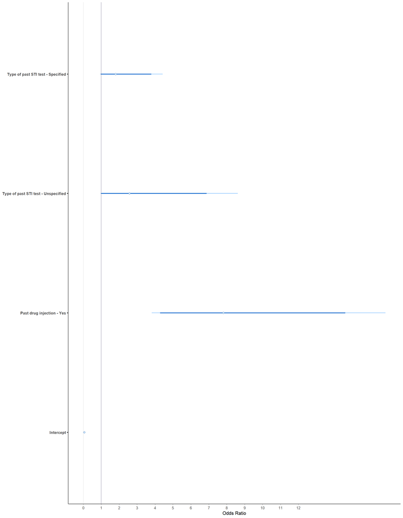

```r
# clean parameters
param_clean <- parameters %>%
  str_replace_all("(b_|\\d+-)| CAD", "") %>%
  str_replace_all("(?<!\\b(?:HCV|HIV|STD|CAD))(?<=\\w)(?=[A-Z])|(?<=\\D)(?=\\d)", " ") %>%
  str_replace_all(" 2; 000", "2000") %>%
  str_replace_all("H I V", "HIV") %>%
  str_replace_all("H C V", "HCV") %>%
  str_replace_all("S T D", "STD")

param_clean <- c("Intercept", "Past drug injection - Yes", "Type of past STI test - Unspecified", "Type of past STI test - Specified")

color_scheme_set("brightblue")

OR.plot <-
  mcmc_intervals(array %>% exp(), # turn logodds into odds
                 pars = parameters, # select which parameters to show
                 prob = 0.89, # set 89% CrI
                 prob_outer = 0.95, # set 95% CrI
                 outer_size = 0.5, # set sizes
                 inner_size = 1,
                 point_size = 2)+
scale_x_continuous(breaks = seq(0,12,1)) +
scale_y_discrete(labels = param_clean)+ # set limits
  geom_vline(xintercept = 1, color = "#36325c", alpha = 0.5)+
  # geom_vline(xintercept = 0, color = "white")+
  labs(x = "Odds Ratio")

OR.plot
```

Extract the OR of all predictors into a dataframe

```r
summary(sub_test[[n_final]], prob = 0.89)
```

```
 Family: bernoulli
  Links: mu = logit
Formula: stbbi.pos ~ PastInjectDrugs + TypePastSTD
   Data: training_set_imp (Number of observations: 296)
  Draws: 4 chains, each with iter = 2000; warmup = 1000; thin = 1;
         total post-warmup draws = 4000

Population-Level Effects:
                        Estimate Est.Error l-89% CI u-89% CI Rhat Bulk_ESS
Intercept                  -3.00      0.41    -3.67    -2.37 1.00     1731
PastInjectDrugs1MYes        2.06      0.38     1.45     2.68 1.00     3168
TypePastSTDNotspecified     0.92      0.63    -0.00     1.93 1.00     1250
TypePastSTDSpecified        0.59      0.45    -0.01     1.33 1.00     1116
                        Tail_ESS
Intercept                   2408
PastInjectDrugs1MYes        3444
TypePastSTDNotspecified     1582
TypePastSTDSpecified        1266

Draws were sampled using sampling(NUTS). For each parameter, Bulk_ESS
and Tail_ESS are effective sample size measures, and Rhat is the potential
scale reduction factor on split chains (at convergence, Rhat = 1).
```

```r
OR_final <- exp(fixef(sub_test[[n_final]], prob = c(0.055, 0.945, 0.025, 0.975))) %>% round(2) %>% as.data.frame()

OR_final
```

```
                        Estimate Est.Error Q5.5 Q94.5 Q2.5 Q97.5
Intercept                   0.05      1.50 0.03  0.09 0.02  0.10
PastInjectDrugs1MYes        7.82      1.47 4.28 14.62 3.82 16.85
TypePastSTDNotspecified     2.50      1.88 1.00  6.88 0.96  8.62
TypePastSTDSpecified        1.81      1.56 0.99  3.80 0.93  4.43
```

### Save files

Only save if there is no overfitting issue

```r
#save
if(sum(submodels.auc.t$Q50) <= sum(submodels.auc$Q50)){
write.csv(submodels_perf, "3_intermediate/projpred/submodels_performance.csv", row.names = F)
ggsave("4_outputs/OR_final_model.png", OR.plot, device = png, width = 7, height = 5)
write.csv(OR_final, file = "4_outputs/OR_final.csv")
ggsave("4_outputs/posteriors_full_model_rev.png",mcmc_imp, device= "png", width = 16, height = 14)
ggsave("3_intermediate/projpred/ppc_density_outcome.png",
       ppc_imp, device = "png", width = 16, height = 7)
}else{
  print("Error: overfitting")
}
```

## **Reference:**

Piironen J, Paasiniemi M, Catalina A, Weber F, Vehtari A (2023). “projpred: Projection Predictive Feature Selection.” R package version 2.8.0, https://mc-stan.org/projpred/.

See vignettes for more information